# Midterm 2

- Student name: Phan Hoang An Nguyen
- Student ID: 100404103

# Time Limit - 6.30 pm to 1.30 am

# 15 + 15 - 30 Marks

# - The exam must be submitted on D2L by 1.30am. No exceptions here.

# - Most Important - Your submitted code should not match a code from the internet or your class peers. If it does, it is a straight 0.

# - The grades for Midterm1 and Midterm2, both will be considered and i will average out the grades.

# - You must submit individually. You will be liable for penalties if your work matches exactly the other person in your class or from the internet. So be careful.

## Problem 1

### The relevant Dataset (CIFAR 100) have been described below.

This is a dataset of 50,000 32x32 color training images and 10,000 test images, labeled over 100 fine-grained classes that are grouped into 20 coarse-grained classes.

- Images have low resolution (32x32).
- Data Source: https://www.cs.toronto.edu/~kriz/cifar.html

Read the website thoroughly.

The dataset can be directly fetched from Keras.io Website for easy incorporation into your code. https://keras.io/api/datasets/cifar100/

### CIFAR-100 Image label detection of provided images

## Prepare a model from the CIFAR-100 dataset using CNN+KERAS. Use 2 Convolution Layers and subsamplings before creating the Neural Model. Choose 512 neurons in the 1st layer and a dropout of 25% in the 2nd hidden layer before using 'SOFTMAX' activation function at the end to obtain the labels. Use 'RELU' in the internal layers as activation function. Use RMSProp as the optimizer and CROSS-Entropy as the loss function. Use 'Accuracy' as the metrics. [7.5 Marks]

## Download the 4 images provided on D2L. These images are of television,camel,wardrobe, and truck. Create a validation dataset using these images and predict the labels using the model of CIFAR-100 created by you as above. [7.5 Marks]

```python
!pip install tensorflow
```

```python
# Load data
import tensorflow as tf
from tensorflow.keras import datasets, layers, models
(train_images, train_labels), (test_images, test_labels) = datasets.cifar100.load_data(label_mode="fine")
```

```python
# Normalize the images to the range [0, 1]
train_images, test_images = train_images / 255.0, test_images / 255.0
train_images.shape, test_images.shape
```

```
((50000, 32, 32, 3), (10000, 32, 32, 3))
```

```python
# Convert labels to one-hot encoding
train_labels = tf.keras.utils.to_categorical(train_labels, 100)
test_labels = tf.keras.utils.to_categorical(test_labels, 100)
train_labels.shape, test_labels.shape
```

```
((50000, 100), (10000, 100))
```

```python
model = models.Sequential()

# First convolutional layer
model.add(layers.Conv2D(32, (3, 3), activation='relu', input_shape=(32, 32, 3)))
model.add(layers.MaxPooling2D((2, 2)))

# Second convolutional layer
model.add(layers.Conv2D(64, (3, 3), activation='relu'))
model.add(layers.MaxPooling2D((2, 2)))

# Flatten the output
model.add(layers.Flatten())

# First dense layer with 512 neurons
model.add(layers.Dense(512, activation='relu'))

# Dropout layer
model.add(layers.Dropout(0.25))

# Output layer with softmax activation
model.add(layers.Dense(100, activation='softmax'))
```

```python
# Compile the model
model.compile(optimizer='rmsprop',
              loss='categorical_crossentropy',
              metrics=['accuracy'])
```

```python
# Train the model
history = model.fit(train_images, train_labels, epochs=10,
                    validation_data=(test_images, test_labels))
```

```
1563/1563 ━━━━━━━━━━━━━━━━━━━━ 8s 5ms/step - accuracy: 0.0990 - loss: 3.9890 - val_accuracy: 0.2542 - val_loss: 3.0820
1563/1563 ━━━━━━━━━━━━━━━━━━━━ 8s 5ms/step - accuracy: 0.2778 - loss: 2.9442 - val_accuracy: 0.3198 - val_loss: 2.7229
1563/1563 ━━━━━━━━━━━━━━━━━━━━ 8s 5ms/step - accuracy: 0.3570 - loss: 2.5411 - val_accuracy: 0.3656 - val_loss: 2.5028
1563/1563 ━━━━━━━━━━━━━━━━━━━━ 8s 5ms/step - accuracy: 0.4182 - loss: 2.2572 - val_accuracy: 0.3754 - val_loss: 2.5434
1563/1563 ━━━━━━━━━━━━━━━━━━━━ 8s 5ms/step - accuracy: 0.4650 - loss: 2.0421 - val_accuracy: 0.3963 - val_loss: 2.4115
1563/1563 ━━━━━━━━━━━━━━━━━━━━ 7s 5ms/step - accuracy: 0.5141 - loss: 1.8452 - val_accuracy: 0.4002 - val_loss: 2.4908
1563/1563 ━━━━━━━━━━━━━━━━━━━━ 7s 5ms/step - accuracy: 0.5491 - loss: 1.6742 - val_accuracy: 0.3972 - val_loss: 2.6533
1563/1563 ━━━━━━━━━━━━━━━━━━━━ 7s 5ms/step - accuracy: 0.5916 - loss: 1.5037 - val_accuracy: 0.3816 - val_loss: 2.8034
1563/1563 ━━━━━━━━━━━━━━━━━━━━ 7s 5ms/step - accuracy: 0.6245 - loss: 1.3868 - val_accuracy: 0.3903 - val_loss: 2.9107
1563/1563 ━━━━━━━━━━━━━━━━━━━━ 7s 5ms/step - accuracy: 0.6491 - loss: 1.2663 - val_accuracy: 0.3950 - val_loss: 3.2177
```

```python
# Evaluate the model
test_loss, test_acc = model.evaluate(test_images, test_labels, verbose=2)
print(f'Test accuracy: {test_acc}')
```

```
313/313 - 0s - 1ms/step - accuracy: 0.3950 - loss: 3.2177
Test accuracy: 0.39500001072883606
```

- Load JPG images for validation

```python
import pandas as pd
import numpy as np
import matplotlib.pyplot as plt
from tensorflow.keras.preprocessing import image
image_paths = ["television.jpg", "camel.jpg", "wardrobe.jpg", "truck.jpg"]

# Function to load and preprocess the images
def load_and_preprocess_image(image_path):
    img = image.load_img(image_path, target_size=(32,32))
    img_array = image.img_to_array(img)
    img_array = img_array / 255.0  # Normalize the image to the range [0, 1]
    return img_array
```

```python
# Load and preprocess all images
validation_images = np.array([load_and_preprocess_image(img_path) for img_path in image_paths])
```

```python
# Predict the labels for the validation images
predictions = model.predict(validation_images)
```

```
1/1 ━━━━━━━━━━━━━━━━━━━━ 0s 33ms/step
```

```python
# Get the predicted class indices
predicted_class_indices = np.argmax(predictions, axis=1)
predicted_class_indices
```

```
array([60, 89, 87, 89], dtype=int64)
```

```python
# CIFAR-100 class names
cifar100_labels = [
    'apple', 'aquarium_fish', 'baby', 'bear', 'beaver', 'bed', 'bee', 'beetle', 'bicycle', 'bottle', 'bowl',
    'boy', 'bridge', 'bus', 'butterfly', 'camel', 'can', 'castle', 'caterpillar', 'cattle', 'chair', 'chimpanzee',
    'clock', 'cloud', 'cockroach', 'couch', 'crab', 'crocodile', 'cup', 'dinosaur', 'dolphin', 'elephant', 'flatfish',
    'forest', 'fox', 'girl', 'hamster', 'house', 'kangaroo', 'keyboard', 'lamp', 'lawn_mower', 'leopard', 'lion',
    'lizard', 'lobster', 'man', 'maple_tree', 'motorcycle', 'mountain', 'mouse', 'mushroom', 'oak_tree', 'orange',
    'orchid', 'otter', 'palm_tree', 'pear', 'pickup_truck', 'pine_tree', 'plain', 'plate', 'poppy', 'porcupine',
    'possum', 'rabbit', 'raccoon', 'ray', 'road', 'rocket', 'rose', 'sea', 'seal', 'shark', 'shrew', 'skunk',
    'skyscraper', 'snail', 'snake', 'spider', 'squirrel', 'streetcar', 'sunflower', 'sweet_pepper', 'table', 'tank',
    'telephone', 'television', 'tiger', 'tractor', 'train', 'trout', 'tulip', 'turtle', 'wardrobe', 'whale', 'willow_tree',
    'wolf', 'woman', 'worm'
]
```

```python
# Map the predicted class indices to the actual class names
predicted_class_names = [cifar100_labels[i] for i in predicted_class_indices]
```

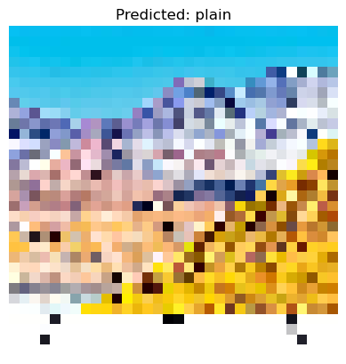

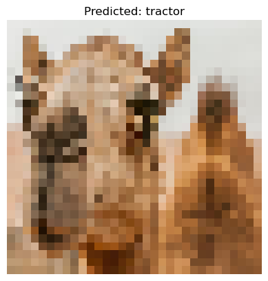

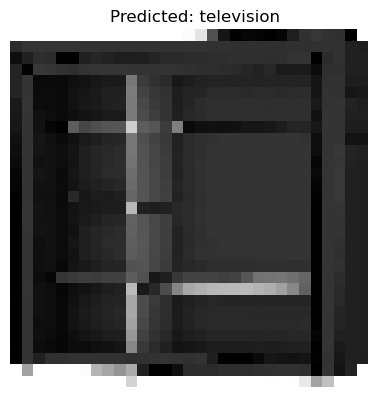

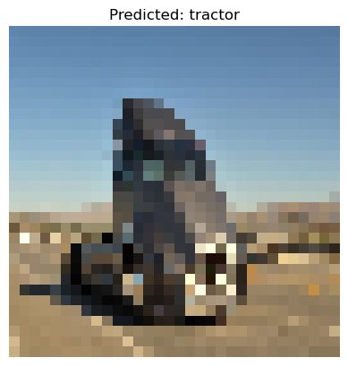

```python
# Display the images along with their predicted labels
for img_path, predicted_class in zip(image_paths, predicted_class_names):
    img = image.load_img(img_path, target_size=(32, 32))
    plt.imshow(img)
    plt.title(f"Predicted: {predicted_class}")
    plt.axis('off')
    plt.show()
```

- Very poor accuracy by the model above (~39%) so it was not supprised it produced inaccurate prediction for all 4 images
- We might be able to predict better if the training data from CIFAR-100 has higher resolution instead of 32x32 so that the validation images didn't need to resize to 32x32

## Problem 2

## Perform Text Classification on the tweet data about COVID19. The tweets have been pulled from Twitter and manual tagging has been done on them. The relevant CSV file have been attached in D2L.

### 1. Use the original Tweet File for your problem 2's analysis. [2 Marks]

### 2. Properly remove punctuations, stopwords and any words of length 1 or 2. [3 Marks]

### 3. Get the wordcloud (as mentioned in the code) after applying step 1 and step 2 (This has not been done in the code). [2 Marks]

### 4. Change number of Topics to 20 in the Gensim LDAMulticore and draw the visualisation. Also figure out, about how many topic clusters could be ideal for such application.[3 Marks]

### 5. Write a complete code using TF-IDF along with Random Forest Classifier to build a Tweet Sentiment classification Model.Use your own discretion to determine the relevant hyperparameters and model parameters. Make sure to provide justification while dropping a column. Remember this is a multiclass classification problem. Give the relevant precision and recall for the model.[5 Marks]

## Columns:

## 1) Location

## 2) Tweet At

## 3) Original Tweet

## 4) Sentiment (To be predicted)

```python
!pip install pyLDAvis
```

```python
!pip install wordcloud
```

```python
!pip install gensim
```

```python
# Load library
import gensim
from gensim import corpora, models
import pyLDAvis
import pyLDAvis.gensim_models as gensimvis
import matplotlib.pyplot as plt
%matplotlib inline
```

```python
# Load data
df = pd.read_csv('Tweets_Corona_NLP.csv',encoding='ISO-8859-1')
df.head()
```

|  | UserName | ScreenName | Location | TweetAt | OriginalTweet | Sentiment |
| --- | --- | --- | --- | --- | --- | --- |
| 0 | 3799 | 48751 | London | 16-03-2020 | @MeNyrbie @Phil_Gahan @Chrisitv https://t.co/i... | Neutral |
| 1 | 3800 | 48752 | UK | 16-03-2020 | advice Talk to your neighbours family to excha... | Positive |
| 2 | 3801 | 48753 | Vagabonds | 16-03-2020 | Coronavirus Australia: Woolworths to give elde... | Positive |
| 3 | 3802 | 48754 | NaN | 16-03-2020 | My food stock is not the only one which is emp... | Positive |
| 4 | 3803 | 48755 | NaN | 16-03-2020 | Me, ready to go at supermarket during the #COV... | Extremely Negative |

```python
import nltk
nltk.download('stopwords')
```

```
True
```

```python
import string
from nltk.corpus import stopwords

# Load stopwords
stop_words = set(stopwords.words('english'))

# Function to clean text
def clean_text(text):
    # Remove punctuation
    text = text.translate(str.maketrans('', '', string.punctuation))
    # Remove stopwords and words of length 1 or 2
    words = text.split()
    words = [word for word in words if word.lower() not in stop_words and len(word) > 2]
    return ' '.join(words)
```

```python
# Remove punctuation, stopwords
df['OriginalTweet'] = df['OriginalTweet'].apply(clean_text)
df['OriginalTweet']
```

```
0        MeNyrbie PhilGahan Chrisitv httpstcoiFz9FAn2Pa...
1        advice Talk neighbours family exchange phone n...
2        Coronavirus Australia Woolworths give elderly ...
3        food stock one empty PLEASE dont panic ENOUGH ...
4        ready supermarket COVID19 outbreak paranoid fo...
                               ...
41152    Airline pilots offering stock supermarket shel...
41153    Response complaint provided citing COVID19 rel...
41154    know itÂs getting tough KameronWilds rationin...
41155    wrong smell hand sanitizer starting turn coron...
41156    TartiiCat Well newused Rift going 70000 Amazon...
Name: OriginalTweet, Length: 41157, dtype: object
```

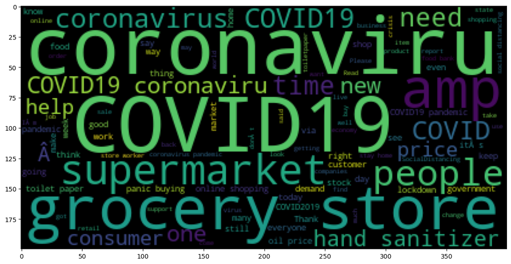

```python
# Wordcloud
from wordcloud import WordCloud #visualization techniques for #frequently repeated texts
wc = WordCloud(
    background_color='black',
    max_words = 100,
    random_state = 42,
    max_font_size=110
    )

wc.generate(' '.join(df['OriginalTweet']))
plt.figure(figsize=(30,7))
plt.imshow(wc)
plt.show()
```

```python
from gensim import corpora
import nltk
from nltk.corpus import stopwords
documents = df['OriginalTweet'].tolist()

# remove common words and tokenize
texts = [
    [word for word in document.lower().split() if word not in stop_words]
    for document in documents
]

dictionary = corpora.Dictionary(texts)
corpus = [dictionary.doc2bow(text) for text in texts]
```

```python
from gensim import corpora, models
tfidf = models.TfidfModel(corpus)

corpus_tfidf = tfidf[corpus]
```

```python
lda_model = gensim.models.LdaMulticore(corpus_tfidf,
                                       num_topics=20,
                                       id2word = dictionary,
                                       passes = 16,
                                       workers=8)
```

```python
top_topics = lda_model.top_topics(corpus_tfidf)
num_topics = 20
# Average topic coherence is the sum of topic coherences of all topics, divided by the number of topics.
avg_topic_coherence = sum([t[1] for t in top_topics]) / num_topics
print('Average topic coherence: %.4f.' % avg_topic_coherence)
```

```
Average topic coherence: -16.7435.
```

```python
# Visualize topics clustering
pyLDAvis.enable_notebook()
vis = gensimvis.prepare(lda_model, corpus, dictionary)
pyLDAvis.display(vis)
```

[interactive chart not shown]

- Many clusters were overlapped from the above so perhaps 20 topics are too many
- Use Coherence score to check how many cluster/number of topics is optimal (<20 topics)

```python
from gensim.models import CoherenceModel

def compute_coherence_values(dictionary, corpus_tfidf, texts, limit, start=2, step=3):
    coherence_values = []
    model_list = []
    for num_topics in range(start, limit, step):
        model = gensim.models.LdaMulticore(corpus_tfidf, num_topics=num_topics, id2word=dictionary, passes=10, workers=2)
        model_list.append(model)
        coherencemodel = CoherenceModel(model=model, texts=texts, dictionary=dictionary, coherence='c_v')
        coherence_values.append(coherencemodel.get_coherence())
    return model_list, coherence_values

model_list, coherence_values = compute_coherence_values(dictionary, corpus_tfidf, texts, start=2, limit=20, step=6)
```

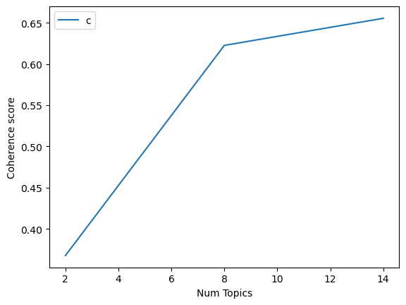

```python
import matplotlib.pyplot as plt
# Plot the result
limit = 20
start = 2
step = 6
x = range(start, limit, step)
plt.plot(x, coherence_values)
plt.xlabel("Num Topics")
plt.ylabel("Coherence score")
plt.legend(("coherence_values"), loc='best')
plt.show()
```

- The optimal number of topics in this case are 14 according to the coherence score (higher = better)
- UserName and Screename are unique ID so they are irrelevant for our model -> Drop them

```python
# Drop first and 2nd column
df = df.drop(df.columns[[0, 1]], axis=1)
df.head()
```

|  | Location | TweetAt | OriginalTweet | Sentiment |
| --- | --- | --- | --- | --- |
| 0 | London | 16-03-2020 | MeNyrbie PhilGahan Chrisitv httpstcoiFz9FAn2Pa... | Neutral |
| 1 | UK | 16-03-2020 | advice Talk neighbours family exchange phone n... | Positive |
| 2 | Vagabonds | 16-03-2020 | Coronavirus Australia Woolworths give elderly ... | Positive |
| 3 | NaN | 16-03-2020 | food stock one empty PLEASE dont panic ENOUGH ... | Positive |
| 4 | NaN | 16-03-2020 | ready supermarket COVID19 outbreak paranoid fo... | Extremely Negative |

```python
df.info()
```

```
<class 'pandas.core.frame.DataFrame'>
RangeIndex: 41157 entries, 0 to 41156
Data columns (total 4 columns):
 #   Column         Non-Null Count  Dtype
---  ------         --------------  -----
 0   Location       32567 non-null  object
 1   TweetAt        41157 non-null  object
 2   OriginalTweet  41157 non-null  object
 3   Sentiment      41157 non-null  object
dtypes: object(4)
memory usage: 1.3+ MB
```

```python
df['Location'].isnull().sum()
```

```
8590
```

```python
df['TweetAt'].value_counts()
```

```
TweetAt
20-03-2020    3448
19-03-2020    3215
25-03-2020    2979
18-03-2020    2742
21-03-2020    2653
22-03-2020    2114
23-03-2020    2062
17-03-2020    1977
08-04-2020    1881
07-04-2020    1843
06-04-2020    1742
24-03-2020    1480
09-04-2020    1471
13-04-2020    1428
26-03-2020    1277
05-04-2020    1131
10-04-2020    1005
02-04-2020     954
11-04-2020     909
03-04-2020     810
12-04-2020     803
04-04-2020     767
16-03-2020     656
01-04-2020     630
27-03-2020     345
31-03-2020     316
14-04-2020     284
29-03-2020     125
30-03-2020      87
28-03-2020      23
Name: count, dtype: int64
```

- Drop Location column because there are so many missing values
- Drop TweetAt column because we predict based on the contents of the tweet, not TimeSeries data

```python
df_final = df.drop(df.columns[[0, 1]], axis=1)
df_final.head()
```

|  | OriginalTweet | Sentiment |
| --- | --- | --- |
| 0 | MeNyrbie PhilGahan Chrisitv httpstcoiFz9FAn2Pa... | Neutral |
| 1 | advice Talk neighbours family exchange phone n... | Positive |
| 2 | Coronavirus Australia Woolworths give elderly ... | Positive |
| 3 | food stock one empty PLEASE dont panic ENOUGH ... | Positive |
| 4 | ready supermarket COVID19 outbreak paranoid fo... | Extremely Negative |

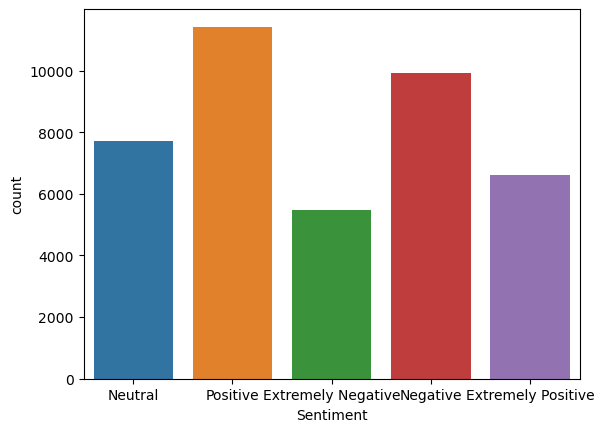

```python
# Plot pie chart of target variable
import seaborn as sns
sns.countplot(x='Sentiment',data=df_final)
```

- We have multiclass labels in this case for target variable, plus they are not equally distributed so we might need to get the weighted values of Recall, precision later instead of macro

```python
# Replace categorical value into numerical
df_final['Sentiment'] = df_final['Sentiment'].replace({'Extremely Positive': 5, 'Positive': 4, 'Neutral': 3, 'Negative': 2, 'Extremely Negative': 1})
df_final['Sentiment'].value_counts()
```

```
Sentiment
4    11422
2     9917
3     7713
5     6624
1     5481
Name: count, dtype: int64
```

- Transform text data into TFID vector

```python
from sklearn.feature_extraction.text import TfidfVectorizer

tfidf = TfidfVectorizer(max_features=5000)

# Transform text data
X = tfidf.fit_transform(df_final['OriginalTweet'])

# Target variable
y = df_final['Sentiment']
```

```python
from sklearn.model_selection import train_test_split
X_train, X_test, y_train, y_test = train_test_split(X, y, test_size=0.2, random_state=42)
```

- Apply RandomForest classification

```python
from sklearn.ensemble import RandomForestClassifier

rf_classifier = RandomForestClassifier(n_estimators=100, random_state=42)

# Train the model
rf_classifier.fit(X_train, y_train)
```

```
RandomForestClassifier(random_state=42)
```

```python
from sklearn.metrics import classification_report, precision_score, recall_score

# Predict on the test set
y_pred = rf_classifier.predict(X_test)

# Generate classification report
report = classification_report(y_test, y_pred, target_names=['Extremely Negative', 'Negative','Neutral','Postive','Extremely Positive'])
print(report)
```

```
                    precision    recall  f1-score   support

Extremely Negative       0.60      0.45      0.51      1056
          Negative       0.49      0.46      0.47      2006
           Neutral       0.56      0.74      0.63      1553
           Postive       0.49      0.55      0.52      2287
Extremely Positive       0.63      0.44      0.52      1330

          accuracy                           0.53      8232
         macro avg       0.55      0.53      0.53      8232
      weighted avg       0.54      0.53      0.53      8232
```

```python
# Calculate precision and recall
precision = precision_score(y_test, y_pred, average='weighted')
recall = recall_score(y_test, y_pred, average='weighted')

print(f'Precision: {precision}')
print(f'Recall: {recall}')
```

```
Precision: 0.540066139803714
Recall: 0.5338921282798834
```

- We have pretty good Precision and Recall here (54% and 53.38% respectively)